# p8130_hw3_jsg2145

Jared Garfinkel

10/25/2019

## Problem 2

This is a dataset of the survival time of different types of cancer.

This dataset is 64 rows by 2 columns.

There are 5 types of organs in the dataset.

Count of Subjects.

| Stomach | Bronchus | Colon | Ovary | Breast |
| --- | --- | --- | --- | --- |
| 13 | 17 | 17 | 6 | 11 |

| Organ | Min | Qrt 1 | Median | Qrt 3 | Max |
| --- | --- | --- | --- | --- | --- |
| Stomach | 25 | 46.00 | 124 | 396.0 | 1112 |
| Bronchus | 20 | 72.00 | 155 | 245.0 | 859 |
| Colon | 20 | 189.00 | 372 | 519.0 | 1843 |
| Ovary | 89 | 239.75 | 406 | 1039.5 | 2970 |
| Breast | 24 | 723.00 | 1166 | 1692.5 | 3808 |

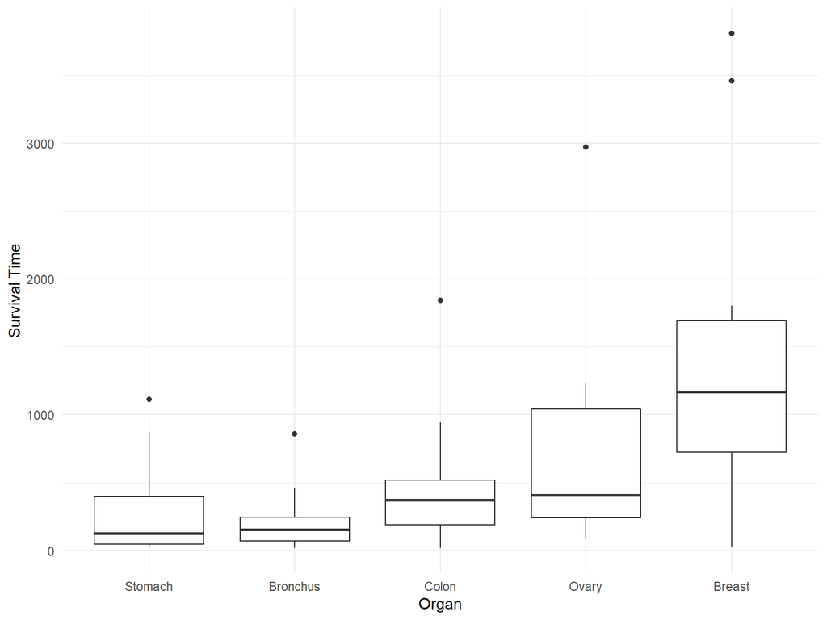

|  | Df | Sum Sq | Mean Sq | F value | Pr(>F) |
| --- | --- | --- | --- | --- | --- |
| organ | 4 | 11535761 | 2883940.1 | 6.433437 | 0.0002295 |
| Residuals | 59 | 26448144 | 448273.6 | NA | NA |

$H_0: \bar{X_1} = \bar{X_2} = ... = \bar{X_n}$

$H_1: \bar{X_i} \ne \bar{X_j}, i \ne j$

Reject $H_0$ when $F_{stat} > F_{crit} = F_{k-1,~n-k,~1-\alpha/2}=F_{4,~59,~.995}$ = 4.1475764

Fail to reject $H_0$ when $F_{stat} \le F_{crit}$

$F_{stat} = \frac{SS~Between/(k-1)}{SS~Within/(n-k)} = \frac{2883940}{448274}$ = 6.4334313

Since $F_{stat} > F_{crit}$, there is sufficient evidence to conclude a significant difference between the

the sample means (p = .0002295). We conduct adjusted pairwise testing to determine which pairs are different.

```
##
##  Pairwise comparisons using t tests with pooled SD
##
## data:  surv_df$survival and surv_df$organ
##
##          Stomach Bronchus Colon   Ovary
## Bronchus 1.00000 -        -       -
## Colon    1.00000 1.00000  -       -
## Ovary    0.75283 0.38575  1.00000 -
## Breast   0.00153 0.00025  0.00608 1.00000
##
## P value adjustment method: bonferroni
```

```
##   Tukey multiple comparisons of means
##     1% family-wise confidence level
##
## Fit: aov(formula = .)
##
## $organ
##                        diff       lwr       upr     p adj
## Bronchus-Stomach  -74.41176 -189.5960   40.7725 0.9981461
## Colon-Stomach     171.41176   56.2275  286.5960 0.9568289
## Ovary-Stomach     598.33333  444.0361  752.6306 0.3772923
## Breast-Stomach   1109.90909  981.8335 1237.9846 0.0013962
## Colon-Bronchus    245.82353  138.5928  353.0542 0.8208402
## Ovary-Bronchus    672.74510  524.2909  821.1993 0.2271084
## Breast-Bronchus  1184.32086 1063.3483 1305.2934 0.0002385
## Ovary-Colon       426.92157  278.4674  575.3758 0.6659115
## Breast-Colon      938.49733  817.5248 1059.4699 0.0053072
## Breast-Ovary      511.57576  352.9108  670.2408 0.5630900
```

```
##
##   Dunnett's test for comparing several treatments with a control :
##     95% family-wise confidence level
##
## $Breast
##                       diff    lwr.ci    upr.ci    pval
## Stomach-Breast  -1109.9091 -1796.332 -423.4862 0.00057 ***
## Bronchus-Breast -1184.3209 -1832.675 -535.9666   9e-05 ***
## Colon-Breast     -938.4973 -1586.852 -290.1431 0.00229 **
## Ovary-Breast     -511.5758 -1361.943  338.7917 0.36663
##
## ---
## Signif. codes:  0 '***' 0.001 '**' 0.01 '*' 0.05 '.' 0.1 ' ' 1
```

In Bonferroni, Tukey, and Dunnett adjustments a change is made to alpha

to correct for the family-wise error rate. These results show that in all

three methods, survival times of patients with breast cancer were significantly

different from stomach cancer, bronchus cancer, and colon cancer at alpha = 0.01.

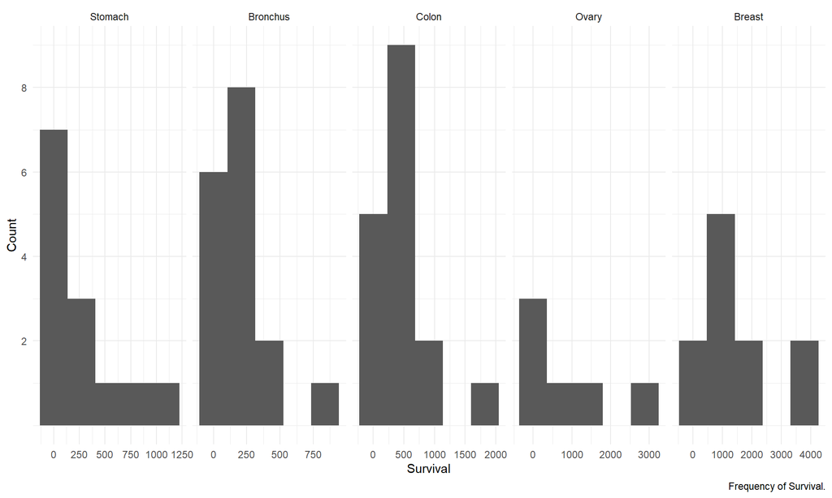

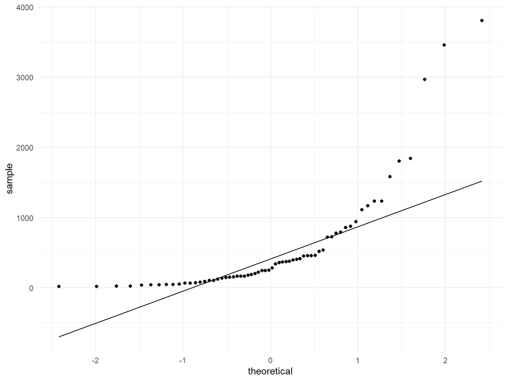

```
##
##  Shapiro-Wilk normality test
##
## data:  uhat
## W = 0.8068, p-value = 9.981e-08
```

$H_0$: The data are sampled from a population having a normal distribution

$H_1$: The data are sampled from a population not having a normal distribution

An observation of the distribution of data in this dataset shows the data is

not normally distributed. A qq-plot allows one to visualize the observations compared

to the theoretical normal. The Shapiro-Wilk normality test confirms this, returning

a very low p-value, indicating that the assumption that the data are normal can be

rejected. One solution to this is to use a non-parametric test that depends on ranked

values rather than on a normality assumption. A Kruskal-Wallis test is acceptable here

because it extends the Wilcoxon rank-sum test to more than two groups.

```
##
##  Kruskal-Wallis rank sum test
##
## data:  survival by organ
## Kruskal-Wallis chi-squared = 14.954, df = 4, p-value = 0.004798
```

This test confirms there are significant differences between the survival times

of patients with different types of cancer at a significance level of 0.01. Compare the Kruskal-Wallis

rank sum test to the parametric test, which had a p-value of .00023. The Kruskal-Wallis test

is more conservative. With further pairwise testing it is possible to determine

which pairs of groups are significantly different.

```
##
##  Pairwise comparisons using Wilcoxon rank sum test
##
## data:  surv_df$survival and surv_df$organ
##
##          Stomach Bronchus Colon Ovary
## Bronchus 1.000   -        -     -
## Colon    0.945   0.113    -     -
## Ovary    0.874   0.459    1.000 -
## Breast   0.184   0.055    0.193 1.000
##
## P value adjustment method: bonferroni
```

This table shows that without the normality assumption, none of the groups are

significantly different with a Bonferroni adjustment.

## Problem 3

| Treatment | Sample Size | Average # of Episodes in a Year | Standard Error |
| --- | --- | --- | --- |
| placebo | 56 | 1.1 | 0.2 |
| iron | 54 | 1.4 | 0.2 |
| zinc | 54 | 0.7 | 0.1 |
| zinc_iron | 55 | 0.8 | 0.1 |

The mean of the groups is a weighted average.

$\mu_{group} = \frac{n_1*\mu_1+n_2*\mu_2}{n_1+n_2}$

The effect size is $\mu_{non-zinc}-\mu_{zinc}$ = 1.25-.75 = 0.5 episodes per year

The standard deviation of the groups can be considered to be the standard error

times the square root of the sample size.

$se = \sqrt{\frac{\sigma^2}{n}},~\sigma = se*\sqrt{n}$

| Treatment | Sample Size | Average # of Episodes in a Year | Standard Error | Standard Deviation | Variance |
| --- | --- | --- | --- | --- | --- |
| placebo | 56 | 1.1 | 0.2 | 1.50 | 2.2500 |
| iron | 54 | 1.4 | 0.2 | 1.47 | 2.1609 |
| zinc | 54 | 0.7 | 0.1 | 0.73 | 0.5329 |
| zinc_iron | 55 | 0.8 | 0.1 | 0.74 | 0.5476 |

Because the standard deviations are very similar they can be assumed to be the same.

So, the variance of the groups can be calculated using pooled variance.

$s^2 = \frac{(n_1-1)*s_{1}^{2}+(n_2-1)*s_{2}^{2}}{n_1+n_2-2}$

| cats | n | u | var |
| --- | --- | --- | --- |
| non_zinc | 110 | 1.25 | 2.20 |
| zinc | 109 | 0.75 | 0.54 |

The sample size can be calculated using the following equations for equal allocations:

$n = \frac{(\sigma_{1}^{2}+\sigma_{2}^{2})(z_{1-\alpha/2}+z_{1-\beta})^2}{\Delta^2}$

$z_{1-\alpha/2}$ = 1.959964

$z_{1-\beta}$ = 0.8416212

So,

= $\frac{(2.2+0.54)(1.96+.84)^2}{(.5)^2}$

= 85.9264 = 85.9 ~ 86

Each group should have 86 subjects to reach this power and significance.

For the sample size of unequal allocations, the following equations apply:

$n_1 = \frac{(\sigma_{1}^{2}+\sigma_{2}^{2}/k)(z_{1-\alpha/2}+z_{1-\beta})^2}{\Delta^2}$

$n_2 = \frac{(k*\sigma_{1}^{2}+\sigma_{2}^{2})(z_{1-\alpha/2}+z_{1-\beta})^2}{\Delta^2}$

So,

$n_1 = \frac{(0.54+2.2/2)(z_{1-\alpha/2}+z_{1-\beta})^2}{(.5)^2}$

= 51.4304 = 51.4 ~ 52

$n_2 = \frac{(2*.54+2.2)(z_{1-\alpha/2}+z_{1-\beta})^2}{(.5)^2}$

= 102.8608 = 102.9 ~ 103

The non-zinc group should have 103 subjects, and the zinc group should have 52 subjects.